# Burlington Tree Health Project

Morgan Swain

10/11/2021

## Introduction

Now more than ever, it is essential to preserve our green areas to protect the planet from pollution, climate change, and deforestation. As UVM students, we care deeply about the sustainability of not only our campus, but the urban areas surrounding it in the city of Burlington. The data we are investigating comes from the Burlington City Arborists to keep track of all the trees planted by the city in business, residential, and park areas. It will give us insight into how well citizens, students, and faculty are keeping the state of our natural areas in. If certain areas have trees in particularly worse condition, this is how we will learn in order to make a change and preserve their health. Last updated in November, 2020, it is an observational study that measures the species, location, size, age, and condition of each tree. There may be some bias in the condition variable, because that could be subjective, but mainly all the other variables are quantitative measurements that cannot be biased. The only cleaning that must be done for the data is converting all the zeros to NAs and removing the NAs.

```r
trees <- read.csv('I_Burlington_Trees(2) (1).csv')
tibble(trees)
```

```
## # A tibble: 12,836 × 15
##    Geo.Point    zone_id site_id modified park  landuse site_typ species diameter
##    <chr>        <chr>     <int> <chr>    <chr> <chr>   <chr>    <chr>      <int>
##  1 44.44854546… ward 5     2933 2013-10  ""    "resid… Tree     arborv…        2
##  2 44.44969801… ward 5     2936 2013-10  ""    "resid… Tree     linden…       16
##  3 44.44975152… ward 5     2937 2013-10  ""    "resid… Tree     linden…       13
##  4 44.45999045… ward 5       29 2011-07  ""    "apart… Plantin… unknown        0
##  5 44.45991207… ward 5       30 2011-07  ""    "apart… Plantin… unknown        0
##  6 44.45978004… ward 5       31 2015-05  ""    "apart… Tree     mapl,r…       41
##  7 44.45951936… ward 5       34 2011-07  ""    "apart… Plantin… unknown        0
##  8 44.45904433… ward 5       37 2011-07  ""    "apart… Tree     maacki…        5
##  9 44.45824290… ward 5       46 2011-07  ""    ""      Tree     unknown        3
## 10 44.45860035… ward 5       48 2015-11  ""    "apart… Tree     mapl,r…       21
## # … with 12,826 more rows, and 6 more variables: height <int>, spread <int>,
## #   trunks <int>, conditn <int>, appraise <int>, planted <int>
```

```r
trees_numeric <- data.frame(trees$diameter, trees$height, trees$spread, trees$trunks, trees$conditn)
tibble(trees_numeric)
```

```
## # A tibble: 12,836 × 5
##    trees.diameter trees.height trees.spread trees.trunks trees.conditn
##             <int>        <int>        <int>        <int>         <int>
##  1              2            5            5            1            80
##  2             16           50           30            1            70
##  3             13           45           25            1            80
##  4              0            0            0            0             0
##  5              0            0            0            0             0
##  6             41           45           35            1            70
##  7              0            0            0            0             0
##  8              5           15           12            1            80
##  9              3           15           10            1            70
## 10             21           45           31            1            70
## # … with 12,826 more rows
```

```r
trees_new <- trees %>% mutate(ratio = (height/diameter)) %>% separate(Geo.Point,c("Latitude","Longitude"),sep=",")
trees_new$Latitude <- as.double(trees_new$Latitude)
trees_new$Longitude <- as.double(trees_new$Longitude)
tibble(trees_new)
```

```
## # A tibble: 12,836 × 17
##    Latitude Longitude zone_id site_id modified park  landuse    site_typ species
##       <dbl>     <dbl> <chr>     <int> <chr>    <chr> <chr>      <chr>    <chr>
##  1     44.4     -73.2 ward 5     2933 2013-10  ""    "residenc… Tree     arborv…
##  2     44.4     -73.2 ward 5     2936 2013-10  ""    "residenc… Tree     linden…
##  3     44.4     -73.2 ward 5     2937 2013-10  ""    "residenc… Tree     linden…
##  4     44.5     -73.2 ward 5       29 2011-07  ""    "apartmen… Plantin… unknown
##  5     44.5     -73.2 ward 5       30 2011-07  ""    "apartmen… Plantin… unknown
##  6     44.5     -73.2 ward 5       31 2015-05  ""    "apartmen… Tree     mapl,r…
##  7     44.5     -73.2 ward 5       34 2011-07  ""    "apartmen… Plantin… unknown
##  8     44.5     -73.2 ward 5       37 2011-07  ""    "apartmen… Tree     maacki…
##  9     44.5     -73.2 ward 5       46 2011-07  ""    ""         Tree     unknown
## 10     44.5     -73.2 ward 5       48 2015-11  ""    "apartmen… Tree     mapl,r…
## # … with 12,826 more rows, and 8 more variables: diameter <int>, height <int>,
## #   spread <int>, trunks <int>, conditn <int>, appraise <int>, planted <int>,
## #   ratio <dbl>
```

## Correlation Plots

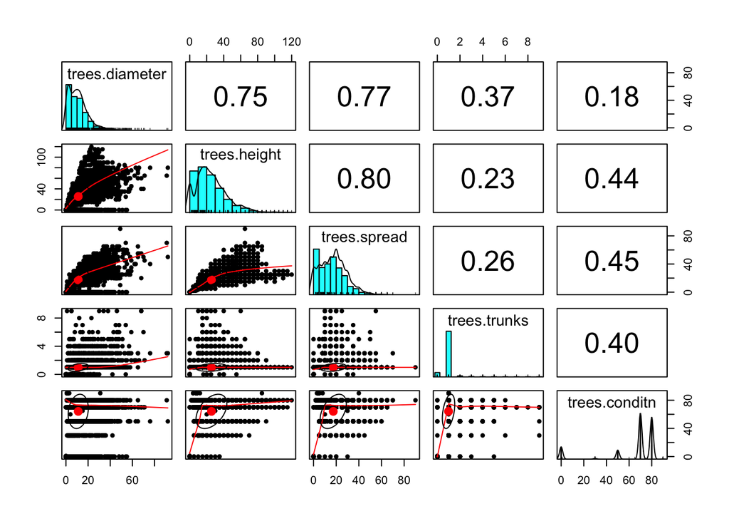

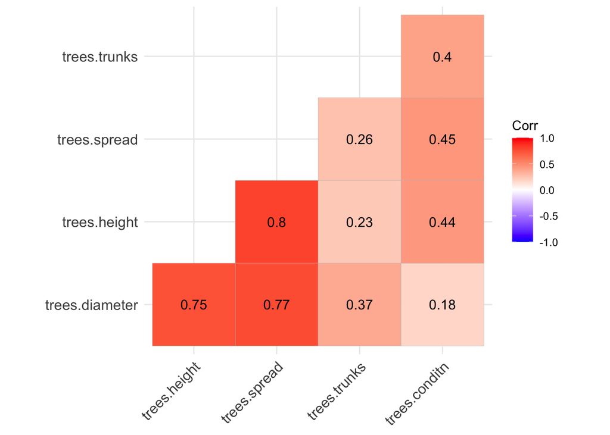

The map below shows the locations of all of the planting sites that were documented in the dataset. The color of the point on the map shows what type of planting site it is. Yellow points represent trees, red points are stumps, cyan points are planting stumpites, and purple points represent tree removal sites. From the map, it is shown that most of the planting sites that have been recorded are on street lines. This could in part due to the fact that the Burlington City Arborists are only responsible for planting sites on public land, which includes mostly areas on or close to streets. There are significantly more points that are trees than any other planting site type. The trees are more densely populated in central Burlington compared to the North End, where the points are slightly further away from eachother. There are also many more stumps documented in central Burlington than any other area on the map. There are significantly more planting stumpites in the data in comparison to removal sites, showing that there are more trees being planted Burlington than there are trees being taken down.

```r
pal <- colorFactor(
  palette = c('red', 'cyan', 'purple', 'yellow'),
  domain = c('Stump', 'Planting Stumpite', 'Removal', 'Tree')
)
leaflet(trees_new) %>%
  addTiles() %>%
  setView(lat = 44.475, lng = -73.212, zoom = 12) %>%
  addCircles(lng = ~Longitude, lat = ~Latitude, weight = 1, radius = 10, color = ~pal(site_typ))
```

[interactive chart not shown]